## Appendix

This appendix contains supporting information describing the analytical approach used to answer questions 1-4.

#### Question 1

Using the lm() function, paramaters were calculated to find the equations for these abatement curves:

**Sector A:**

MC<sub>A</sub> = 0.513x + 1.663

**Sector B:**

MC<sub>B</sub> =5.577$\sqrt{x}$ + -6.44

**Sector C:**

MC<sub>C</sub> = 1.39x + -54.797

**Sector D:**

MC<sub>D</sub> = 0.004$x^2$ + -0.06$x$ + 2.099

Each of these regressions was compared to regressions with other potential forms, with the regression resulting in the highest *r<sup>2</sup>* value being chosen as the most accurate.

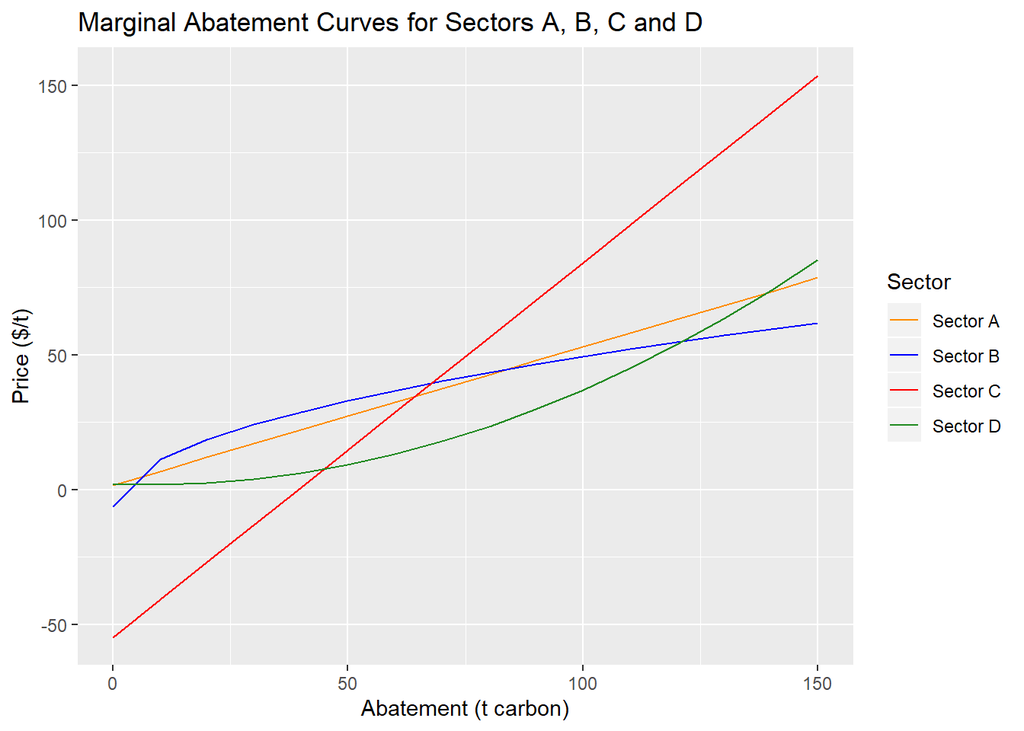

#### Question 2

The demand (or marginal willingess to pollute) curves for carbon pollution was derived from the abatement curves by substituting X = $Q_0$ - $Q$ into the abatement functions, using provided current emissions levels for each sector for $Q_0$.

**Sector A:**

MC<sub>A</sub> = 0.513x + 1.663

MWTPollute<sub>A</sub> = 0.513(170 - x) + 1.663

**Sector B:**

MC<sub>B</sub> =5.577$\sqrt{x}$ + -6.44

MWTPollute<sub>B</sub> = 5.577$\sqrt{}$(200 - x) + -6.44

**Sector C:**

MC<sub>C</sub> = 1.39x + -54.797

MWTPollute<sub>C</sub> = 1.39(230 - x) + -54.797

**Sector D:**

MC<sub>D</sub> = 0.004$x^2$ + -0.06$x$ + 2.099

MWTPollute<sub>D</sub> = 0.004(300 - $x$)$^2$ + -0.06(300 - $x$) + 2.099

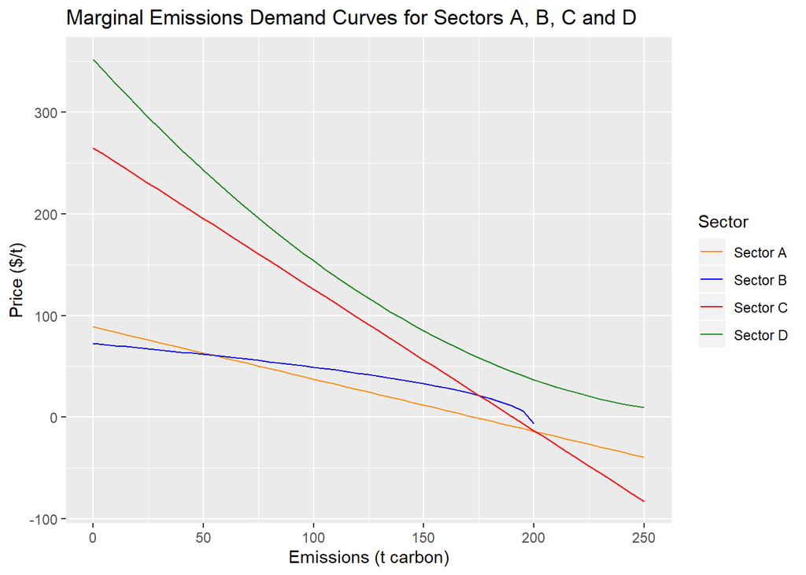

#### Question 3

##### a. Cap on Carbon

A cap on carbon will reduce each sector’s carbon emissions by 100 tons. To calculate the cost to each sector, the integral of the marginal supply curve was calculated for the interval (0, 100). The resulting cost to sector A is $2731.25, the cost to sector B is $3074.12, and the cost to sector C is $1471.04.

The total cost to country X from a cap on carbon was calculated by summing the cost of each sector. The total cost to country X is $7276.41.

##### b. Tax

A properly calculated tax can achieve the same desired 300-ton reduction in emissions, not by limiting the sectors, but by taxing them so it will only be efficient to emit up to a certain level. To calculate the socially optimal tax, the tax was factored into each sector’s abatement curve:

Abatement<sub>A</sub> = (tax -1.663)/0.513

Abatement<sub>B</sub> = (tax - -6.44)/5.577$^2$

Abatement<sub>C</sub> = (tax - -54.797)/1.39

The abatement for each sector was then summed together and the tax was altered until the total abatement for country X was 300 tons. The tax at this point was $54.35. The resulting cost to sector A is $6533.87, the cost to sector B is $8462.62, and the cost to sector C is $8215.68.

The total tax revenue for country X was calculated by subtracting the abatement for each sector from the overall emissions at the socially optimal tax of $54.35. The tax revenue for country X is $16303.72.

The total cost to country X from a tax on carbon would be the sum of these costs less the country’s tax revenue. The total cost to country X is $6908.45.

##### c. Cap and Trade

Cap and trade allows country X to set a cap on total carbon emissions and allow each sector 100 tons of emissions. These 100 credits can be traded among the sectors. A sector would do this if the market price of 1 ton of carbon credit is greater than their benefit of emitting that additional ton. To find that marginal willingness to pollute curves for each sector were rearranged for Q from the abatement function as follows:

Q<sub>A</sub>= -(MWTP - 1.663 - 0.513*170)/0.513

Q<sub>B</sub> = -((MWTP - -6.44/5.577)$^2$ + 200

Q<sub>C</sub> = -(MWTP - -54.797 - 1.39*230)/1.39

#### Question 4

To determine if it is beneficial for country Y to enter country X’s carbon market. To calculate, sector D’s abatement function was arranged for Q as was done for sectors A, B, and C in 3c above:

Q<sub>D</sub> = 585*.5 - $\sqrt{(250*MWTP - 937*.5)}$

The abatement for sector D was summed with all sectors in country X and the MWTP was altered until total emissions reached 600 tons. The MWTP with both countries participating in the carbon market is $37.6. The cost to sector A is $2501.22, the cost to sector B is $2844.63, the cost to sector C is $689.4, and the cost to sector D is $-2452.8, meaning that they would gain money. The overall cost to countries X and Y is $3582.45.